# 言語処理100本ノック／第4章: 形態素解析

```python
# ファイルの入っているフォルダを先に指定しておく
import subprocess
cmd = "cd /Users/S/PycharmProjects/NLP/"
subprocess.call(cmd.strip().split(" "))
```

```
0
```

インストールの際には、[こちらのサイト](http://shogo82148.github.io/blog/2015/06/02/mecab-in-python3/)などを参考にすること。なお、cdコマンドでカレントディレクトリを変更してからsetup.pyを実行すること。

```python
import MeCab
```

```python
sample_u = "眼が、とってもいい。青く青く、澄んでいる。美しい夕空を、ながいこと見つめたから、こんなにいい目になったのかしら。しめたものだ。"
mecab = MeCab.Tagger ("-MeCab")
print(mecab.parse(sample_u))
```

```
眼	名詞,一般,*,*,*,*,眼,メ,メ
が	助詞,格助詞,一般,*,*,*,が,ガ,ガ
、	記号,読点,*,*,*,*,、,、,、
とっても	副詞,一般,*,*,*,*,とっても,トッテモ,トッテモ
いい	形容詞,自立,*,*,形容詞・イイ,基本形,いい,イイ,イイ
。	記号,句点,*,*,*,*,。,。,。
青く	形容詞,自立,*,*,形容詞・アウオ段,連用テ接続,青い,アオク,アオク
青く	形容詞,自立,*,*,形容詞・アウオ段,連用テ接続,青い,アオク,アオク
、	記号,読点,*,*,*,*,、,、,、
澄ん	動詞,自立,*,*,五段・マ行,連用タ接続,澄む,スン,スン
で	助詞,接続助詞,*,*,*,*,で,デ,デ
いる	動詞,非自立,*,*,一段,基本形,いる,イル,イル
。	記号,句点,*,*,*,*,。,。,。
美しい	形容詞,自立,*,*,形容詞・イ段,基本形,美しい,ウツクシイ,ウツクシイ
夕空	名詞,一般,*,*,*,*,夕空,ユウゾラ,ユーゾラ
を	助詞,格助詞,一般,*,*,*,を,ヲ,ヲ
、	記号,読点,*,*,*,*,、,、,、
ながい	形容詞,自立,*,*,形容詞・アウオ段,基本形,ながい,ナガイ,ナガイ
こと	名詞,非自立,一般,*,*,*,こと,コト,コト
見つめ	動詞,自立,*,*,一段,連用形,見つめる,ミツメ,ミツメ
た	助動詞,*,*,*,特殊・タ,基本形,た,タ,タ
から	助詞,接続助詞,*,*,*,*,から,カラ,カラ
、	記号,読点,*,*,*,*,、,、,、
こんなに	副詞,助詞類接続,*,*,*,*,こんなに,コンナニ,コンナニ
いい	動詞,自立,*,*,五段・ワ行促音便,連用形,いう,イイ,イイ
目	名詞,接尾,一般,*,*,*,目,メ,メ
に	助詞,格助詞,一般,*,*,*,に,ニ,ニ
なっ	動詞,自立,*,*,五段・ラ行,連用タ接続,なる,ナッ,ナッ
た	助動詞,*,*,*,特殊・タ,基本形,た,タ,タ
の	名詞,非自立,一般,*,*,*,の,ノ,ノ
かしら	助詞,終助詞,*,*,*,*,かしら,カシラ,カシラ
。	記号,句点,*,*,*,*,。,。,。
しめ	動詞,自立,*,*,一段,連用形,しめる,シメ,シメ
た	助動詞,*,*,*,特殊・タ,基本形,た,タ,タ
もの	名詞,非自立,一般,*,*,*,もの,モノ,モノ
だ	助動詞,*,*,*,特殊・ダ,基本形,だ,ダ,ダ
。	記号,句点,*,*,*,*,。,。,。
EOS
```

```python
tagger = MeCab.Tagger ("-Owakati")
result = tagger.parse(sample_u)
print(result)
```

```
眼 が 、 とっても いい 。 青く 青く 、 澄ん で いる 。 美しい 夕空 を 、 ながい こと 見つめ た から 、 こんなに いい 目 に なっ た の かしら 。 しめ た もの だ 。
```

### 前処理

夏目漱石の小説『吾輩は猫である』の文章（neko.txt）をMeCabを使って形態素解析し，その結果をneko.txt.mecabというファイルに保存せよ．このファイルを用いて，以下の問に対応するプログラムを実装せよ．

```python
with open('neko.txt', encoding='utf-8') as novel:
    mecab = MeCab.Tagger ("-MeCab")

    for line in novel:
        MeCabed = mecab.parse(line)
        with open('neko.txt.mecab', mode='a', encoding='utf-8') as new_file: # 追記する cf. http://diveintopython3-ja.rdy.jp/files.html#writing
            new_file.write(MeCabed)
```

### No.30

形態素解析結果（neko.txt.mecab）を読み込むプログラムを実装せよ．ただし，各形態素は表層形（surface），基本形（base），品詞（pos），品詞細分類1（pos1）をキーとするマッピング型に格納し，1文を形態素（マッピング型）のリストとして表現せよ．第4章の残りの問題では，ここで作ったプログラムを活用せよ．

```python
with open('neko.txt.mecab', encoding='utf-8') as mecabed:
    temp = []
    for line in mecabed:
        temp.append(line)
    text = "".join(temp) # 一旦1行ずつリストに追加したものを一つに合わせる
```

```python
import re # 正規表現のために必要
```

```python
pattern = re.compile(r"(?P<surface>.+?)\t(?P<pos>.+?),(?P<pos1>.+?),.+?,.+?,.+?,.+?,(?P<base>.+?),.+?,.+?\n")
cleaned = re.findall(pattern, text) # findallでは、グルーピングしたものだけが抽出される

MC_dict = {}
surface_list = []
base_list = []
pos_list = []
pos1_list = []

for i in cleaned:
    surface, pos, pos1, base = i # 上のグループの順番に合わせること

    surface_list.append(surface)
    base_list.append(base)
    pos_list.append(pos)
    pos1_list.append(pos1)

MC_dict["surface"] = surface_list
MC_dict["base"] = base_list
MC_dict["pos"] = pos_list
MC_dict["pos1"] = pos1_list
```

### No.31

動詞の表層形(surface)をすべて抽出せよ．

```python
import pandas as pd
```

```python
MC_df = pd.DataFrame.from_dict(MC_dict)

col = MC_df.columns.tolist()
col = col[-1:] + col[:-1]
MC_df = MC_df[col]
```

```python
MC_df[5:20]
```

|  | surface | base | pos | pos1 |
| --- | --- | --- | --- | --- |
| 5 | で | だ | 助動詞 | * |
| 6 | ある | ある | 助動詞 | * |
| 7 | 。 | 。 | 記号 | 句点 |
| 8 | 名前 | 名前 | 名詞 | 一般 |
| 9 | は | は | 助詞 | 係助詞 |
| 10 | まだ | まだ | 副詞 | 助詞類接続 |
| 11 | 無い | 無い | 形容詞 | 自立 |
| 12 | 。 | 。 | 記号 | 句点 |
| 13 |  |  | 記号 | 空白 |
| 14 | どこ | どこ | 名詞 | 代名詞 |
| 15 | で | で | 助詞 | 格助詞 |
| 16 | 生れ | 生れる | 動詞 | 自立 |
| 17 | た | た | 助動詞 | * |
| 18 | か | か | 助詞 | 副助詞／並立助詞／終助詞 |
| 19 | とんと | とんと | 副詞 | 一般 |

```python
verb_surface = MC_df.ix[MC_df["pos"]=="動詞", "surface"]
```

```python
verb_surface.head(10)
```

```
16    生れ
22    つか
29     し
33    泣い
39     し
41    いる
47    始め
53     見
59    聞く
86    捕え
Name: surface, dtype: object
```

### No.32

動詞の原形をすべて抽出せよ．

```python
verb_base = MC_df.ix[MC_df["pos"]=="動詞", "base"]
verb_base.head(10)
```

```
16    生れる
22     つく
29     する
33     泣く
39     する
41     いる
47    始める
53     見る
59     聞く
86    捕える
Name: base, dtype: object
```

### No.33

サ変接続の名詞をすべて抽出せよ．

```python
MC_df.ix[(MC_df["pos"]=="名詞") & (MC_df["pos1"]=="サ変接続"), "surface"].head(10)
```

```
20     見当
38     記憶
92      話
187    装飾
233    突起
302    運転
358    記憶
508    分別
596    決心
619    我慢
Name: surface, dtype: object
```

### No.34

2つの名詞が「の」で連結されている名詞句を抽出せよ．

```python
meishiku = []
for i in range(1, len(MC_dict["pos"])): # 最初と最後の行は一つ前の要素がないのでスキップする
    if MC_dict['pos'][i-1] == '名詞' and MC_dict['surface'][i] == 'の' and MC_dict['pos'][i+1] == '名詞':
        #  MC_dictのそれぞれのkeyに対応するvalueはリストだから上のような操作ができる
        meishiku.append("".join([MC_dict['surface'][i-1], MC_dict['surface'][i], MC_dict['surface'][i+1]]))
                # 結果を一度listにして、それをつなげた上でmeishikuリストに投入する
```

```python
meishiku[0:5]
```

```
['彼の掌', '掌の上', '書生の顔', 'はずの顔', '顔の真中']
```

### No.35

名詞の連接（連続して出現する名詞）を最長一致で抽出せよ．

```python
continuous = []
previous = [] # 一つ前に一致したもの

for i in range(1, len(MC_dict["pos"])):

        if MC_dict["pos"][i] == "名詞":
            temp = []
            temp.append(i) # 登場したところが名詞なら場所を記録する

            j = i + 1
            while MC_dict["pos"][j] == "名詞": # 次の要素が名詞である限りtempに場所を記録する
                temp.append(j)
                j += 1

            wordlen = len(temp) # 今調べているものが何連続しているか

            flag = False # 連続した名詞として、リストに追加するか否かのflag
            if wordlen >= 2: # 2連続以上なら記録する
                flag = True
                for i in temp:
                    if i in previous: # previousには、一つ前に抽出した単語が入っている。for loopのiは一つずつ上がっていくので、
                                              # previousで抽出したものと内容が被ってしまうことがある。その際は追加を避けるためにflagをFalseにする
                        flag = False
                        break # 1つでも被っているものがあれば、for loopから抜けて良い

            if flag is True: # flagがTrueのときのみcontinuousに追加する
                continuous.append(temp)

            previous = temp


extracted = []
for item in continuous: # 上で抽出したのばリスト内のindexであるので、これをsurfaceを利用して文字列に置き換える
    temp = []
    for i in item:
        temp.append(MC_dict["surface"][i])

    if len("".join(temp)) > 1:
        extracted.append("".join(temp))
```

```python
extracted[1:20]
```

```
['一番獰悪',
 '時妙',
 '一毛',
 'その後猫',
 '一度',
 '邸内',
 '三毛',
 '書生以外',
 '四五遍',
 'この間おさん',
 '三馬',
 '御台所',
 'まま奥',
 '住家',
 '終日書斎',
 '勉強家',
 '勉強家',
 '勤勉家',
 '二三ページ']
```

```python
# 初めは間違って最長の名詞だけを抽出していた
continuous = []
maxlen = 0 # 最長の連続数の記録

for i in range(1, len(MC_dict["pos"])):
    temp = []
    if MC_dict["pos"][i] == "名詞":
        temp.append(i) # 登場したところが名詞なら場所を記録する

        j = i + 1
        while MC_dict["pos"][j] == "名詞": # 次の要素が名詞である限りtempに場所を記録する
            temp.append(j)
            j += 1

        wordlen = len(temp) # 今調べているものが何連続しているか

        if wordlen > maxlen:
            continuous = temp # これまで記録しているものより長い長さなら、continuousの中身を置き換える
            maxlen = len(temp)
        elif wordlen == maxlen:
                continuous.append(temp) # これまで記録しているものと同じ長さなら、continuousに追加

    temp = []
```

```python
temp = []
for i in continuous:
    temp.append(MC_dict["surface"][i])
print("".join(temp))
```

```
明治三十八年何月何日戸締り
```

### No.36

文章中に出現する単語とその出現頻度を求め，出現頻度の高い順に並べよ．

```python
from collections import Counter # 各要素の数え上げをするならcollections: http://qiita.com/hatchinee/items/a904c1f8d732a4686c9d

words_frq = []
for word, count in Counter(MC_dict['surface']).most_common():
     words_frq.append((word, count))
```

```python
words_frq[0:10]
```

```
[('の', 9194),
 ('。', 7486),
 ('て', 6868),
 ('、', 6772),
 ('は', 6420),
 ('に', 6243),
 ('を', 6071),
 ('と', 5508),
 ('が', 5337),
 ('た', 3988)]
```

### No.37

出現頻度が高い10語とその出現頻度をグラフ（例えば棒グラフなど）で表示せよ．

```python
import matplotlib.pyplot as plt
```

[figure not shown]

```python
%matplotlib inline
word_list = []
frq_list = []

for word, count in words_frq[0:10]:
    word_list.append(word)
    frq_list.append(int(count))

X = range(1,11)
Y = frq_list
plt.bar(X,Y)
plt.xticks(X, word_list)
plt.xlabel('Word')
plt.ylabel('Frequency')
plt.show()  # inline表示にした際に文字化けしているが、inline表示にしなければ文字化けもなかった。
```

### No.38

単語の出現頻度のヒストグラム（横軸に出現頻度，縦軸に出現頻度をとる単語の種類数を棒グラフで表したもの）を描け．

```python
hist_freq1 = {}
for word, freq in words_frq:
    try:
        hist_freq1[freq] += 1 # ある出現回数が既に登場していたら、登場回数 + 1を行う
    except KeyError:
        hist_freq1[freq] = 1 # 未出のものに上の操作を行うとエラーが出るので、新しく追加する
```

```python
hist_freq = []
for word, freq in words_frq:
    hist_freq.append(freq)
```

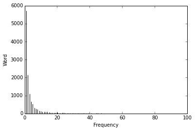

```python
%matplotlib inline
# matplotlibでのhistgramについて:cf. http://akiyoko.hatenablog.jp/entry/2013/06/07/213448
fig = plt.figure()
ax = fig.add_subplot(111)
ax.hist(hist_freq,bins=10000,range=(0,100),normed=False)
ax.set_ylabel('Word')
ax.set_xlabel('Frequency')
plt.show()
```

### No.39

単語の出現頻度順位を横軸，その出現頻度を縦軸として，両対数グラフをプロットせよ．

```python
from collections import Counter # 各要素の数え上げをするならcollections: http://qiita.com/hatchinee/items/a904c1f8d732a4686c9d

words_frq2 = []
rank = 1
rank_list = []
frq_list = []
for word, count in Counter(MC_dict['surface']).most_common():
    rank_list.append(rank)
    frq_list.append(count)
    rank += 1
```

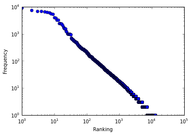

```python
%matplotlib inline
# matplotlibでのhistgramに就て:cf. http://akiyoko.hatenablog.jp/entry/2013/06/07/213448

fig = plt.figure()
ax = fig.add_subplot(111) # プロット領域（1x1分割の1番目に領域を配置せよという意味）
X = range(1, len(rank_list)+1)
Y = frq_list
plt.loglog(X,Y, "o")
plt.xlabel('Ranking')
plt.ylabel('Frequency')
plt.show()
```